# Tipología y Ciclo de Vida de los Datos - Práctica 2

Autores: José Castillo Alba - Hubner Janampa Patilla

Diciembre 2020

# 1 Presentación

## 1.1 Descripción

En esta práctica se elabora un caso práctico orientado a aprender a identificar los datos relevantes para un proyecto analítico y usar las herramientas de integración, limpieza, validación y análisis de las mismas.

## 1.2 Competencias

En esta práctica se desarrollan las siguientes competencias del Máster de Data Science:

- Capacidad de analizar un problema en el nivel de abstracción adecuado a cada situación y aplicar las habilidades y conocimientos adquiridos para abordarlo y resolverlo.
- Capacidad para aplicar las técnicas específicas de tratamiento de datos (integración, transformación, limpieza y validación) para su posterior análisis.

## 1.3 Objetivos

Los objetivos concretos de esta práctica son:

- Aprender a aplicar los conocimientos adquiridos y su capacidad de resolución de problemas en entornos nuevos o poco conocidos dentro de contextos más amplios o multidisciplinares.
- Saber identificar los datos relevantes y los tratamientos necesarios (integración, limpieza y validación) para llevar a cabo un proyecto analítico.
- Aprender a analizar los datos adecuadamente para abordar la información contenida en los datos.
- Identificar la mejor representación de los resultados para aportar conclusiones sobre el problema planteado en el proceso analítico.
- Actuar con los principios éticos y legales relacionados con la manipulación de datos en función del ámbito de aplicación.
- Desarrollar las habilidades de aprendizaje que les permitan continuar estudiando de un modo que tendrá que ser en gran medida autodirigido o autónomo.
- Desarrollar la capacidad de búsqueda, gestión y uso de información y recursos en el ámbito de la ciencia de datos.

# 2 Desarrollo

## 2.1 Descripción del dataset. ¿Por qué es importante y qué pregunta/problema pretende responder?

### 2.1.1 ¿Por qué es importante y qué pregunta?

> El **conjunto de datos** está compuesto por variables físico/químicas de un vino Portugués. Se torna muy interesante para los fabricantes y productores vinicolas conocer que tan bueno o malo es el vino que ofrecen al mercado consumidor.

> La finalidad que se persigue al realizar el análisis de las características del vino es conocer las cantidades y elementos físicos/químicos que influyen a la hora determinar su calidad. Se trata de que técnicos especialistas en la elaboración del vino apoyen sus decisiones basado en criterios estadísticos y análiticos.

### 2.1.2 ¿Cual es el problema pretende responder?

> El problema que pretende responder es el de determinar la calidad del vino, sobre las cantidades y elementos físicos/químicos que lo influyen, ver que elementos fisicos-químicos son mas sensibles a la hora de determinar su calidad.

> En la práctica se va realizar un análisis exploratorio de los datos que iniciará con la limpieza de datos para conocer si existen valores nulos o vacios, identificar outliers, entre otros. En el caso de ser necesario se determinara las variables de importancia en el estudio, talvez normalizar y/o categorizar, luego se procede con el propio análisis de datos para descubrir patrones que nos lleve a una o varias conclusiones.

> Realizamos la lectura inicial del conjunto de datos, el mismo que esta compuesto 12 variables y 1599 observaciones:

```r
df <- read.csv('winequality-red.csv',header=T, sep=",", stringsAsFactors = FALSE)
str(df)
```

```
## 'data.frame':    1599 obs. of  12 variables:
##  $ fixed.acidity       : num  7.4 7.8 7.8 11.2 7.4 7.4 7.9 7.3 7.8 7.5 ...
##  $ volatile.acidity    : num  0.7 0.88 0.76 0.28 0.7 0.66 0.6 0.65 0.58 0.5 ...
##  $ citric.acid         : num  0 0 0.04 0.56 0 0 0.06 0 0.02 0.36 ...
##  $ residual.sugar      : num  1.9 2.6 2.3 1.9 1.9 1.8 1.6 1.2 2 6.1 ...
##  $ chlorides           : num  0.076 0.098 0.092 0.075 0.076 0.075 0.069 0.065 0.073 0.071 ...
##  $ free.sulfur.dioxide : num  11 25 15 17 11 13 15 15 9 17 ...
##  $ total.sulfur.dioxide: num  34 67 54 60 34 40 59 21 18 102 ...
##  $ density             : num  0.998 0.997 0.997 0.998 0.998 ...
##  $ pH                  : num  3.51 3.2 3.26 3.16 3.51 3.51 3.3 3.39 3.36 3.35 ...
##  $ sulphates           : num  0.56 0.68 0.65 0.58 0.56 0.56 0.46 0.47 0.57 0.8 ...
##  $ alcohol             : num  9.4 9.8 9.8 9.8 9.4 9.4 9.4 10 9.5 10.5 ...
##  $ quality             : int  5 5 5 6 5 5 5 7 7 5 ...
```

> El fichero esta compuesto por variables de tipo númericos y enteros:

```r
sapply(df,class)
```

```
##        fixed.acidity     volatile.acidity          citric.acid
##            "numeric"            "numeric"            "numeric"
##       residual.sugar            chlorides  free.sulfur.dioxide
##            "numeric"            "numeric"            "numeric"
## total.sulfur.dioxide              density                   pH
##            "numeric"            "numeric"            "numeric"
##            sulphates              alcohol              quality
##            "numeric"            "numeric"            "integer"
```

Las variables que forman parte del conjunto de datos, encontramos las siguientes:

- **Fixed acidity/acidez fija:** *La mayoría de los ácidos involucrados con el vino o fijos o no volátiles (no se evaporan fácilmente).*
- **Volatile acidity/acidez volátil:** *Cantidad de ácido acético en el vino, que en niveles demasiado altos puede provocar un sabor desagradable a vinagre.*
- **Citric acid/ácido cítrico:** *Encontrado en pequeñas cantidades, el ácido cítrico puede agregar ‘frescura’ y sabor a los vinos.*
- **Residual sugar/azúcar residual:** *Cantidad de azúcar que queda después de que se detiene la fermentación.*
- **Chlorides/cloruros:** *Cantidad de sal en el vino.*
- **Free sulfur dioxide/dióxido de azufre libre:** *La forma libre del SO2 existe en equilibrio entre el SO2 molecular (como gas disuelto) y el ion bisulfito.*
- **Total sulfur dioxide/dióxido de azufre total:** *Cantidad de formas libres y unidas de SO2.*
- **Density/densidad:** *La densidad del agua es cercana a la del agua dependiendo del porcentaje de alcohol y contenido de azúcar.*
- **pH:** *Describe qué tan ácido o básico es un vino en una escala de 0 (muy ácido) a 14 (muy básico); la mayoría de los vinos están entre 3-4.*
- **Sulphates/sulfatos:** *Un aditivo para el vino que puede contribuir a los niveles de dióxido de azufre (SO2), que actúa como antimicrobiano.*
- **Alcohol/alcohol:** *Porcentaje de alcohol contenido en el vino.*
- **Quality/calidad:** *Basado en datos sensoriales, cuya puntuación es entre 0 y 10.*

## 2.2 Integración y selección de los datos de interés a analizar

> Al tratarse de elementos físico/químicos son variables que de alguna forma u otra determinan la calidad del vino, pero se pondrá especial atención a las variables *total.sulfur.dioxide, density y alcohol* ya que considero desde mi punto de vista que son factores relevantes en el vino.

En el mundo de los vinos se puede encontrar una gran variedad con características muy diversas, tales como vinos de mesa, vinos fortificados, vinos espumosos, vinos de postre y vinos compuestos. Aún cuando los vinos se encuentran bajo la misma denominación general, pueden tener características muy diferentes debido **al tipo de uva que se utiliza, a la región de donde esta proceda y a las caracterisitcas del proceso de elaboración** *(GARGIA G, QUINTERO R, LOPEZ M - Biotecnología Alimentaria-2003).*

*La acidez es uno de los sabores fundamentales del vino.* Su proporción va a determinar la sensación de frescor y va incidir en su equilibrio. Encontrando en el vino ácidos orgánicos en los cuales tres de ellos son provenientes de la uva (tártiso, málico y cítrico), y los ácidos produnto de la fermentación y la acción de las bacterias(láctico, succínico, acético).

- Provenientes de la uva: ácido tártiso, málico y cítrico, **obteniendo ácidez fija y acidez total.**
- Originado por la fermentación: ácido láctico, succínico, acético, **obteniendo acidez volátil.** *(PLAZA N. VICTORIA, SUNG K. EUN)*

La *densidad* de un vino puede indicar su contenido en alcohol pero no determina su calidad, por otra parte el *grado de alcohol* es importante para conservar las propiedades del vino pero tampoco es un condicionante de calidad y el *aumento de la acidez volátil* produce un efecto negativo y provoca el picado acético que a la hora de catar se puede percibir aromas y sabores a vinagre. *(LUCAS MARÍA - Los 6 criterios que determinan la calidad en el vino-Noviembre 2015)*

A criterio personal de los autores consideramos que la mayoría de variables del dataset pueden llegar a determinar la calidad del vino, ya que se trata de variaciones físico-quimicas que en altas o bajas cantidades alteran su composición. Pero tomando en cuenta los criterios establecidos en los parráfos anteriores se pondrá especial atención a las variables *acidez fija, acidez volátl, density y alcohol* con el fin de corroborar o descartar si infieren o no en la calidad del vino.

# 3 Limpieza de los datos, ¿Los datos contienen ceros o elementos vacíos?,¿Cómo gestionarías cada uno de estos casos?

> Partimos realizamos un detalle estadístico de las variables para conocer como están distribuidas:

```r
summary(df)
```

```
##  fixed.acidity   volatile.acidity  citric.acid    residual.sugar
##  Min.   : 4.60   Min.   :0.1200   Min.   :0.000   Min.   : 0.900
##  1st Qu.: 7.10   1st Qu.:0.3900   1st Qu.:0.090   1st Qu.: 1.900
##  Median : 7.90   Median :0.5200   Median :0.260   Median : 2.200
##  Mean   : 8.32   Mean   :0.5278   Mean   :0.271   Mean   : 2.539
##  3rd Qu.: 9.20   3rd Qu.:0.6400   3rd Qu.:0.420   3rd Qu.: 2.600
##  Max.   :15.90   Max.   :1.5800   Max.   :1.000   Max.   :15.500
##    chlorides       free.sulfur.dioxide total.sulfur.dioxide    density
##  Min.   :0.01200   Min.   : 1.00       Min.   :  6.00       Min.   :0.9901
##  1st Qu.:0.07000   1st Qu.: 7.00       1st Qu.: 22.00       1st Qu.:0.9956
##  Median :0.07900   Median :14.00       Median : 38.00       Median :0.9968
##  Mean   :0.08747   Mean   :15.87       Mean   : 46.47       Mean   :0.9967
##  3rd Qu.:0.09000   3rd Qu.:21.00       3rd Qu.: 62.00       3rd Qu.:0.9978
##  Max.   :0.61100   Max.   :72.00       Max.   :289.00       Max.   :1.0037
##        pH          sulphates         alcohol         quality
##  Min.   :2.740   Min.   :0.3300   Min.   : 8.40   Min.   :3.000
##  1st Qu.:3.210   1st Qu.:0.5500   1st Qu.: 9.50   1st Qu.:5.000
##  Median :3.310   Median :0.6200   Median :10.20   Median :6.000
##  Mean   :3.311   Mean   :0.6581   Mean   :10.42   Mean   :5.636
##  3rd Qu.:3.400   3rd Qu.:0.7300   3rd Qu.:11.10   3rd Qu.:6.000
##  Max.   :4.010   Max.   :2.0000   Max.   :14.90   Max.   :8.000
```

> Por lo regular cuando se trata de datos faltantes, siempre se denotan por campos vacios o cero. Para este caso particular no se puede asegurar al 100% en el caso de valores con cero que se trate precisamente de valores perdidos ya que se puede tratar de elementos fisico/químicos que realmente pueden ser cero, pero se debe descartar la existencia valores vacios.

> A continuación se verifica que campos tienen valores vacíos:

```r
colSums(is.na(df))
```

```
##        fixed.acidity     volatile.acidity          citric.acid
##                    0                    0                    0
##       residual.sugar            chlorides  free.sulfur.dioxide
##                    0                    0                    0
## total.sulfur.dioxide              density                   pH
##                    0                    0                    0
##            sulphates              alcohol              quality
##                    0                    0                    0
```

> Podemos notar que no existen valores vacios, esto es una bueña señal que permite avanzar con en el análisis de los datos.

## 3.1 Identificación y tratamiento de valores extremos

> Los valores extremos tambien conocidos como outliers, se trata de datos muy alejados de la ditribución normal de una variable (datos anómalos). Al momento de realizar el análisis, la presencia de datos extremos pueden generar estimaciones y/o resultados equivocados, por tal razón se procede a graficar mediante diagrama de cajas para corroborar o descartar la existencia.

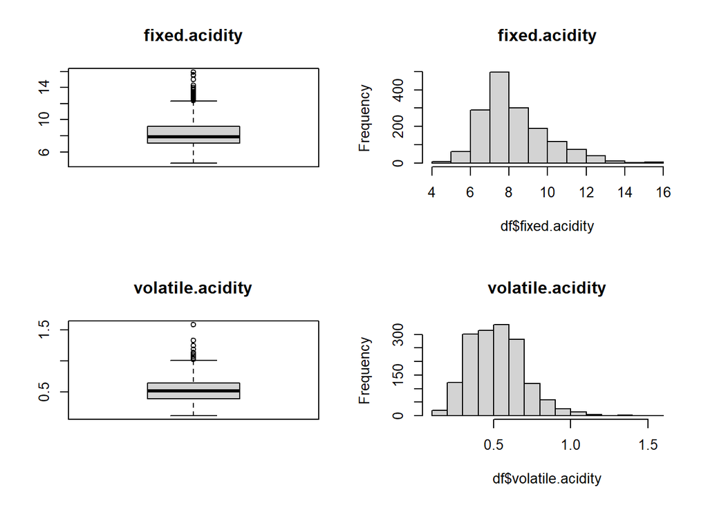

```r
par(mfrow=c(2,2))
boxplot(df$fixed.acidity,main="fixed.acidity")
hist(df$fixed.acidity,main="fixed.acidity")

boxplot(df$volatile.acidity,main="volatile.acidity")
hist(df$volatile.acidity,main="volatile.acidity")
```

```r
boxplot.stats(df$fixed.acidity)$out
```

```
##  [1] 12.8 12.8 15.0 15.0 12.5 13.3 13.4 12.4 12.5 13.8 13.5 12.6 12.5 12.8 12.8
## [16] 14.0 13.7 13.7 12.7 12.5 12.8 12.6 15.6 12.5 13.0 12.5 13.3 12.4 12.5 12.9
## [31] 14.3 12.4 15.5 15.5 15.6 13.0 12.7 13.0 12.7 12.4 12.7 13.2 13.2 13.2 15.9
## [46] 13.3 12.9 12.6 12.6
```

```r
boxplot.stats(df$volatile.acidity)$out
```

```
##  [1] 1.130 1.020 1.070 1.330 1.330 1.040 1.090 1.040 1.240 1.185 1.020 1.035
## [13] 1.025 1.115 1.020 1.020 1.580 1.180 1.040
```

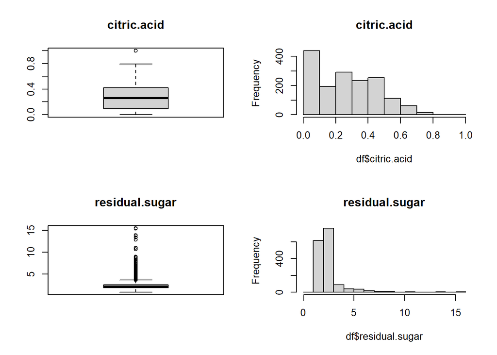

```r
par(mfrow=c(2,2))
boxplot(df$citric.acid,main="citric.acid")
hist(df$citric.acid,main="citric.acid")

boxplot(df$residual.sugar,main="residual.sugar")
hist(df$residual.sugar,main="residual.sugar")
```

```r
boxplot.stats(df$citric.acid)$out
```

```
## [1] 1
```

```r
boxplot.stats(df$residual.sugar)$out
```

```
##   [1]  6.10  6.10  3.80  3.90  4.40 10.70  5.50  5.90  5.90  3.80  5.10  4.65
##  [13]  4.65  5.50  5.50  5.50  5.50  7.30  7.20  3.80  5.60  4.00  4.00  4.00
##  [25]  4.00  7.00  4.00  4.00  6.40  5.60  5.60 11.00 11.00  4.50  4.80  5.80
##  [37]  5.80  3.80  4.40  6.20  4.20  7.90  7.90  3.70  4.50  6.70  6.60  3.70
##  [49]  5.20 15.50  4.10  8.30  6.55  6.55  4.60  6.10  4.30  5.80  5.15  6.30
##  [61]  4.20  4.20  4.60  4.20  4.60  4.30  4.30  7.90  4.60  5.10  5.60  5.60
##  [73]  6.00  8.60  7.50  4.40  4.25  6.00  3.90  4.20  4.00  4.00  4.00  6.60
##  [85]  6.00  6.00  3.80  9.00  4.60  8.80  8.80  5.00  3.80  4.10  5.90  4.10
##  [97]  6.20  8.90  4.00  3.90  4.00  8.10  8.10  6.40  6.40  8.30  8.30  4.70
## [109]  5.50  5.50  4.30  5.50  3.70  6.20  5.60  7.80  4.60  5.80  4.10 12.90
## [121]  4.30 13.40  4.80  6.30  4.50  4.50  4.30  4.30  3.90  3.80  5.40  3.80
## [133]  6.10  3.90  5.10  5.10  3.90 15.40 15.40  4.80  5.20  5.20  3.75 13.80
## [145] 13.80  5.70  4.30  4.10  4.10  4.40  3.70  6.70 13.90  5.10  7.80
```

[figure not shown]

```r
par(mfrow=c(2,2))
boxplot(df$chlorides,main="chlorides")
hist(df$fixed.acidity,main="chlorides")

boxplot(df$free.sulfur.dioxide,main="free.sulfur.dioxide")
hist(df$free.sulfur.dioxide,main="free.sulfur.dioxide")
```

```r
boxplot.stats(df$chlorides)$out
```

```
##   [1] 0.176 0.170 0.368 0.341 0.172 0.332 0.464 0.401 0.467 0.122 0.178 0.146
##  [13] 0.236 0.610 0.360 0.270 0.039 0.337 0.263 0.611 0.358 0.343 0.186 0.213
##  [25] 0.214 0.121 0.122 0.122 0.128 0.120 0.159 0.124 0.122 0.122 0.174 0.121
##  [37] 0.127 0.413 0.152 0.152 0.125 0.122 0.200 0.171 0.226 0.226 0.250 0.148
##  [49] 0.122 0.124 0.124 0.143 0.222 0.039 0.157 0.422 0.034 0.387 0.415 0.157
##  [61] 0.157 0.243 0.241 0.190 0.132 0.126 0.038 0.165 0.145 0.147 0.012 0.012
##  [73] 0.039 0.194 0.132 0.161 0.120 0.120 0.123 0.123 0.414 0.216 0.171 0.178
##  [85] 0.369 0.166 0.166 0.136 0.132 0.132 0.123 0.123 0.123 0.403 0.137 0.414
##  [97] 0.166 0.168 0.415 0.153 0.415 0.267 0.123 0.214 0.214 0.169 0.205 0.205
## [109] 0.039 0.235 0.230 0.038
```

```r
boxplot.stats(df$free.sulfur.dioxide)$out
```

```
##  [1] 52 51 50 68 68 43 47 54 46 45 53 52 51 45 57 50 45 48 43 48 72 43 51 51 52
## [26] 55 55 48 48 66
```

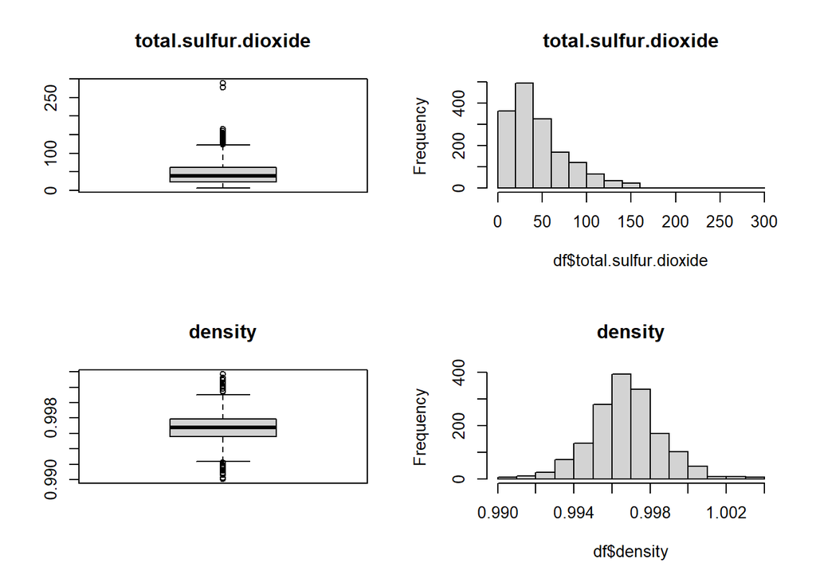

```r
par(mfrow=c(2,2))
boxplot(df$total.sulfur.dioxide,main="total.sulfur.dioxide")
hist(df$total.sulfur.dioxide,main="total.sulfur.dioxide")

boxplot(df$density,main="density")
hist(df$density,main="density")
```

```r
boxplot.stats(df$total.sulfur.dioxide)$out
```

```
##  [1] 145 148 136 125 140 136 133 153 134 141 129 128 129 128 143 144 127 126 145
## [20] 144 135 165 124 124 134 124 129 151 133 142 149 147 145 148 155 151 152 125
## [39] 127 139 143 144 130 278 289 135 160 141 141 133 147 147 131 131 131
```

```r
boxplot.stats(df$density)$out
```

```
##  [1] 0.99160 0.99160 1.00140 1.00150 1.00150 1.00180 0.99120 1.00220 1.00220
## [10] 1.00140 1.00140 1.00140 1.00140 1.00320 1.00260 1.00140 1.00315 1.00315
## [19] 1.00315 1.00210 1.00210 0.99170 0.99220 1.00260 0.99210 0.99154 0.99064
## [28] 0.99064 1.00289 0.99162 0.99007 0.99007 0.99020 0.99220 0.99150 0.99157
## [37] 0.99080 0.99084 0.99191 1.00369 1.00369 1.00242 0.99182 1.00242 0.99182
```

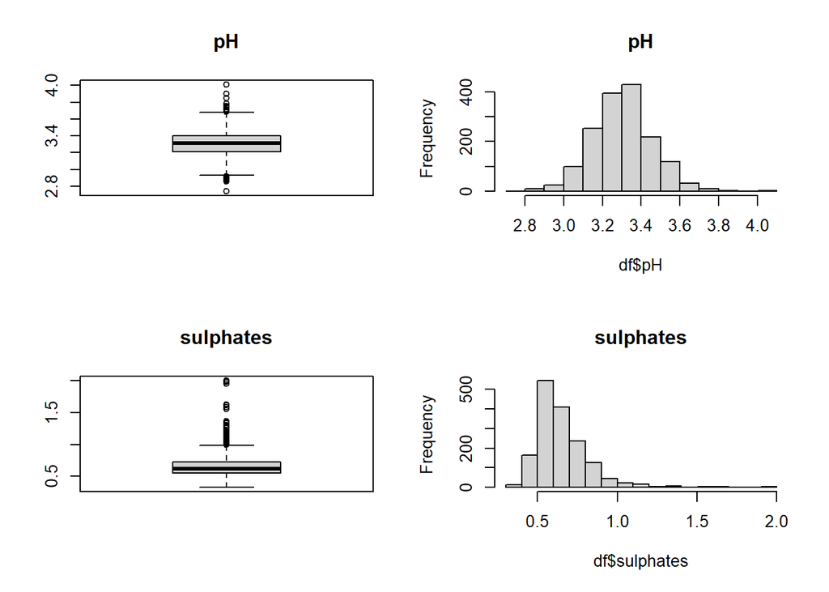

```r
par(mfrow=c(2,2))
boxplot(df$pH,main="pH")
hist(df$pH,main="pH")

boxplot(df$sulphates,main="sulphates")
hist(df$sulphates,main="sulphates")
```

```r
boxplot.stats(df$pH)$out
```

```
##  [1] 3.90 3.75 3.85 2.74 3.69 3.69 2.88 2.86 3.74 2.92 2.92 2.92 3.72 2.87 2.89
## [16] 2.89 2.92 3.90 3.71 3.69 3.69 3.71 3.71 2.89 2.89 3.78 3.70 3.78 4.01 2.90
## [31] 4.01 3.71 2.88 3.72 3.72
```

```r
boxplot.stats(df$sulphates)$out
```

```
##  [1] 1.56 1.28 1.08 1.20 1.12 1.28 1.14 1.95 1.22 1.95 1.98 1.31 2.00 1.08 1.59
## [16] 1.02 1.03 1.61 1.09 1.26 1.08 1.00 1.36 1.18 1.13 1.04 1.11 1.13 1.07 1.06
## [31] 1.06 1.05 1.06 1.04 1.05 1.02 1.14 1.02 1.36 1.36 1.05 1.17 1.62 1.06 1.18
## [46] 1.07 1.34 1.16 1.10 1.15 1.17 1.17 1.33 1.18 1.17 1.03 1.17 1.10 1.01
```

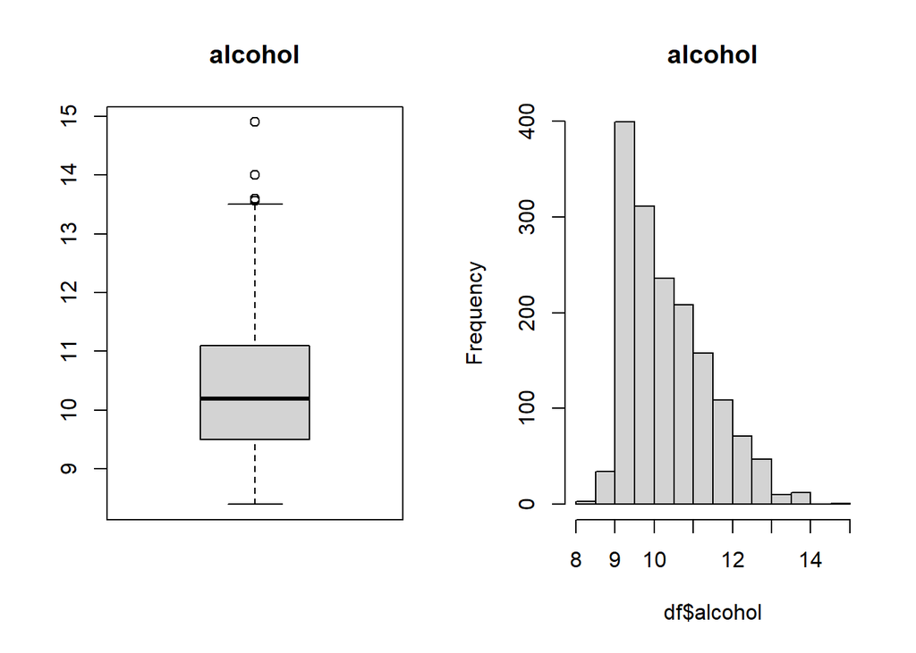

```r
par(mfrow=c(1,2))
boxplot(df$alcohol,main="alcohol")
hist(df$alcohol,main="alcohol")
```

```r
boxplot.stats(df$alcohol)$out
```

```
##  [1] 14.00000 14.00000 14.00000 14.00000 14.90000 14.00000 13.60000 13.60000
##  [9] 13.60000 14.00000 14.00000 13.56667 13.60000
```

> En **conclusión** la elaboración de los vinos se ve influenciado por los elementos físico/químico que lo componen de esa manera se puede obtener una gran variedad, por tal razón no se trata de valores extremos sino datos reales que se presentan.

# 4 Análisis de los datos.

## 4.1 Selección de los grupos de datos que se quieren analizar/comparar (planificación de los análisis a aplicar)

> A continuación de determina los grupos del conjunto de datos que pueden resultar interesantes para su posterior análisis:

```r
TotalResidualSugar <- quantile(df$residual.sugar,probs =0.75)
df.altoResidualSugar <- df[df$residual.sugar>=TotalResidualSugar,]$quality
df.bajoResidualSugar <- df[df$residual.sugar<TotalResidualSugar,]$quality
```

```r
totalSulfurDioxide <- quantile(df$total.sulfur.dioxide,probs =0.75)
df.altoTotalSulfurDioxide <- df[df$total.sulfur.dioxide>=totalSulfurDioxide,]$quality
df.bajoTotalSulfurDioxide <- df[df$total.sulfur.dioxide<totalSulfurDioxide,]$quality
```

```r
TotalDensity <- quantile(df$density,probs =0.75)
df.altoAlcohol <- df[df$density>=TotalDensity,]$quality
df.bajoAlcohol <- df[df$density<TotalDensity,]$quality
```

```r
Totalalcohol <- quantile(df$alcohol,probs =0.75)
df.altoAlcohol <- df[df$alcohol>=Totalalcohol,]$quality
df.bajoAlcohol <- df[df$alcohol<Totalalcohol,]$quality
```

## 4.2 Comprobación de la normalidad y homogeneidad de la varianza.

> Verificamos si las variables presentan normalidad, aunque en los apartados anteriores ya se hizo un análisis previo de la distribución. Esta vez vamos a graficar mediante quartile e histograma.

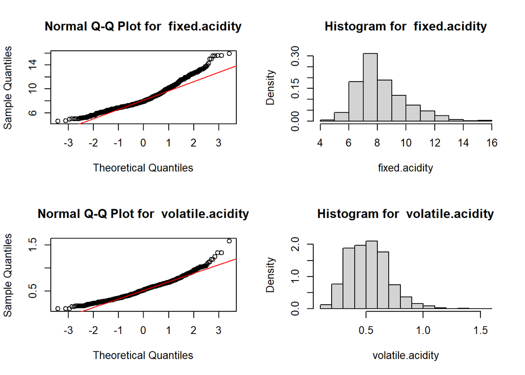

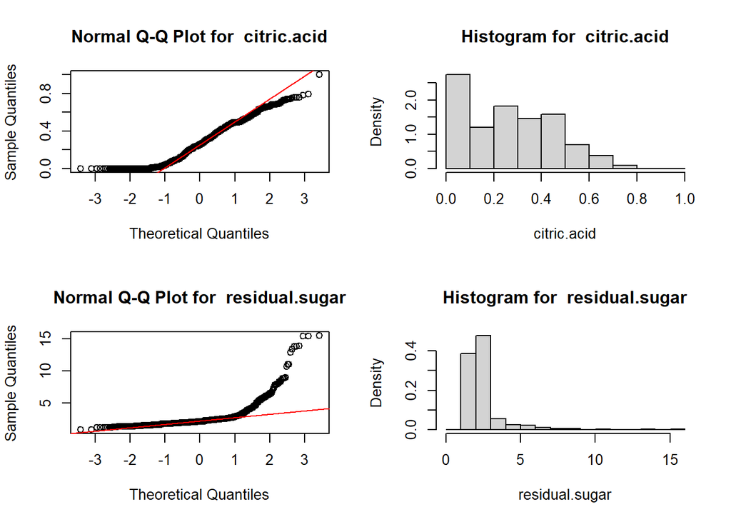

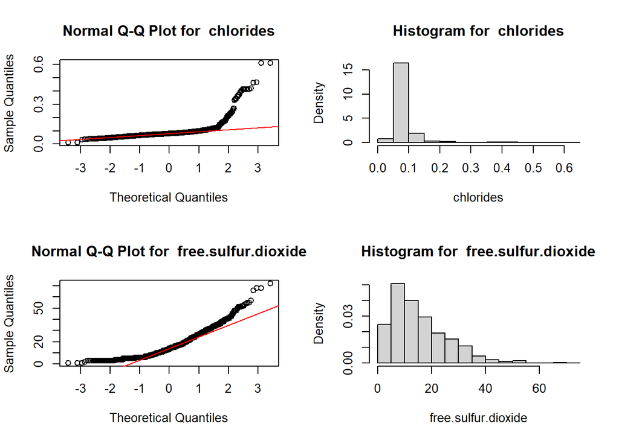

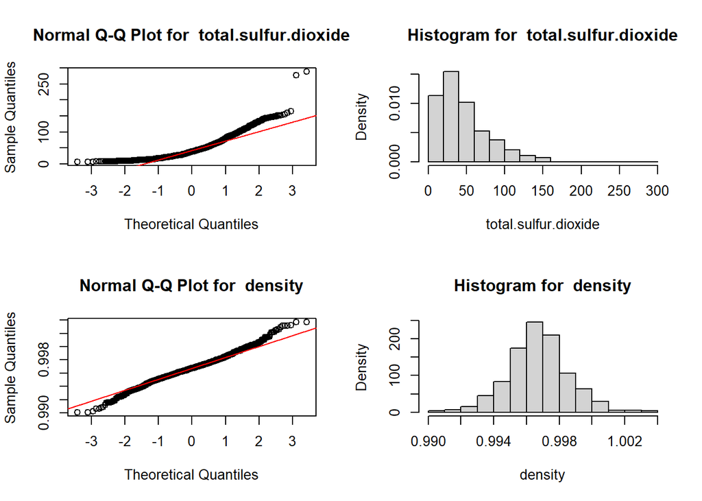

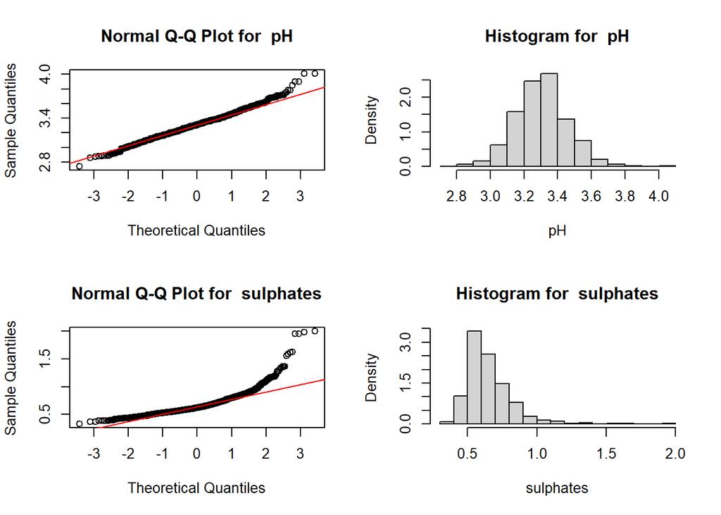

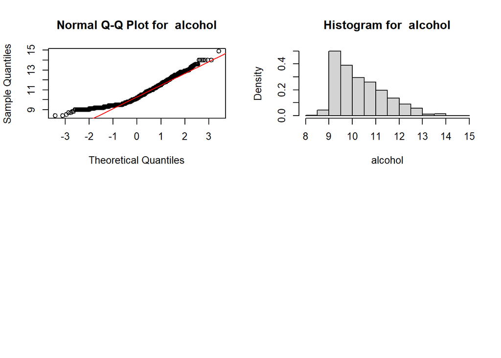

```r
par(mfrow=c(2,2))
for(i in 1:ncol(df)-1) {
if (is.numeric(df[,i])){
qqnorm(df[,i],main = paste("Normal Q-Q Plot for ",colnames(df)[i]))
qqline(df[,i],col="red")
hist(df[,i],
main=paste("Histogram for ", colnames(df)[i]),
xlab=colnames(df)[i],freq =FALSE)
}
}
```

#### 4.2.0.1 Test estadístico de Lilliefors

En este apartado se evalúa las variables mediante el test de Lilliefors para comprobar normalidad.

```r
library("nortest")
alpha =0.05
col.names = colnames(df)
for (i in 1:ncol(df)) {
  if (i == 1) cat("Variables que no siguen una distribución normal:\n")
    if (is.integer(df[,i]) |is.numeric(df[,i])) {
        p_val = lillie.test(df[,i])$p.value
    if (p_val < alpha) {
        cat(col.names[i])
        # Format output
    if (i <ncol(df) - 1) cat(", ")
    if (i %% 3 == 0) cat("\n")
    }
    }
}
```

```
## Variables que no siguen una distribución normal:
## fixed.acidity, volatile.acidity, citric.acid,
## residual.sugar, chlorides, free.sulfur.dioxide,
## total.sulfur.dioxide, density, pH,
## sulphates, alcoholquality
```

> El test Lilliefors, nos indica que las variables realmente no siguen una distribución normal, este suceso se da principalmente por los valores extremos que se analizaron en los apartados anteriores, pero como lo habiamos manifestado no se pueden eliminar porque son parte del análisis.

> Aunque ya se ha corroborado que las variables no presentan normalidad, pero a modo de ejemplo y de manera detallada vamos a conocer el *p-valor de las residual.sugar, total.sulfur.dioxide, density y alcohol*.

```r
lillie.test(x = df$residual.sugar)
```

```
##
##  Lilliefors (Kolmogorov-Smirnov) normality test
##
## data:  df$residual.sugar
## D = 0.26068, p-value < 2.2e-16
```

```r
lillie.test(x = df$total.sulfur.dioxide)
```

```
##
##  Lilliefors (Kolmogorov-Smirnov) normality test
##
## data:  df$total.sulfur.dioxide
## D = 0.12098, p-value < 2.2e-16
```

```r
lillie.test(x = df$density)
```

```
##
##  Lilliefors (Kolmogorov-Smirnov) normality test
##
## data:  df$density
## D = 0.044787, p-value = 6.252e-08
```

```r
lillie.test(x = df$alcohol)
```

```
##
##  Lilliefors (Kolmogorov-Smirnov) normality test
##
## data:  df$alcohol
## D = 0.12145, p-value < 2.2e-16
```

> Como se puede apreciar el p-valor de las variables analizadas están por debajo del 0.05 por lo que efectivamente no cumplen normalidad.

> Aplicando el **Teorema del Límite Central** el mismo que manifiesta, dada una muestra suficientemente grande (>30), la distribución de las medias muestrales seguirá una distribución normal.

## 4.3 Aplicación de pruebas estadísticas para comparar los grupos de datos. En función de los datos y el objetivo del estudio, aplicar pruebas de contraste de hipótesis, correlaciones, regresiones, etc. Aplicar al menos tres métodos de análisis diferentes

### 4.3.1 Correlaciones:

> Se procede a realizar un análisis de correlaciones con las distintas variables con la finalidad de conocer cuales presentan mayor peso a la hora de determinar la calidad del vino (variable **quality**):

```r
corr_matrix <- matrix(nc =2,nr =0)
colnames(corr_matrix) <- c("estimate","p-value")

# Calcular el coeficiente de correlación para cada variable cuantitativa
# con respecto al campo "quality"
for (i in 1:(ncol(df) - 1)) {
  if (is.integer(df[,i]) |is.numeric(df[,i])) {
    spearman_test = cor.test(df[,i],df[,length(df)],method ="spearman")
    corr_coef =spearman_test$estimate
    p_val =spearman_test$p.value
# Add row to matrix
    pair = matrix(ncol =2,nrow =1)
    pair[1][1] =corr_coef
    pair[2][1] =p_val
    corr_matrix <- rbind(corr_matrix, pair)
    rownames(corr_matrix)[nrow(corr_matrix)] <- colnames(df)[i]
  }
}
```

[output not shown]

```r
print(corr_matrix)
```

```
##                         estimate      p-value
## fixed.acidity         0.11408367 4.801220e-06
## volatile.acidity     -0.38064651 2.734944e-56
## citric.acid           0.21348091 6.158952e-18
## residual.sugar        0.03204817 2.002454e-01
## chlorides            -0.18992234 1.882858e-14
## free.sulfur.dioxide  -0.05690065 2.288322e-02
## total.sulfur.dioxide -0.19673508 2.046488e-15
## density              -0.17707407 9.918139e-13
## pH                   -0.04367193 8.084594e-02
## sulphates             0.37706020 3.477695e-55
## alcohol               0.47853169 2.726838e-92
```

> De acuerdo a los resultados obtenidos las 3 principales variables que tienen mayor relevancia son: _alcohol, volatile.acidity y sulphates.

### 4.3.2 Contraste de Hipótesis:

> Realizamos algunos contrastes de hipótesis para algunas variables.

**Contraste de hipótesis unilateral sobre la cantidad de azúcar (df.bajoResidualSugar):**

**Hipótesis nula**

$$H_0: \mu_1 = \mu_2$$

**Hipótesis alternativa**

$$H_1: \mu_1< \mu_2$$

```r
t.test(df.bajoResidualSugar, df$quality,alternative ="less")
```

```
##
##  Welch Two Sample t-test
##
## data:  df.bajoResidualSugar and df$quality
## t = -0.026921, df = 2532, p-value = 0.4893
## alternative hypothesis: true difference in means is less than 0
## 95 percent confidence interval:
##        -Inf 0.04986301
## sample estimates:
## mean of x mean of y
##  5.635193  5.636023
```

**Contraste de hipótesis unilateral sobre la cantidad total de Dióxido de sulfuro (df.altoTotalSulfurDioxide):**

**Hipótesis nula**

$$H_0: \mu_1 = \mu_2$$

**Hipótesis alternativa**

$$H_1: \mu_1< \mu_2$$

```r
t.test(df.altoTotalSulfurDioxide, df$quality,alternative ="less")
```

```
##
##  Welch Two Sample t-test
##
## data:  df.altoTotalSulfurDioxide and df$quality
## t = -6.677, df = 752.79, p-value = 2.368e-11
## alternative hypothesis: true difference in means is less than 0
## 95 percent confidence interval:
##        -Inf -0.1922452
## sample estimates:
## mean of x mean of y
##  5.380835  5.636023
```

**Contraste de hipótesis unilateral sobre la cantidad de alcohol (df.altoAlcohol):**

**Hipótesis nula**

$$H_0: \mu_1 = \mu_2$$

```r
t.test(df.altoAlcohol, df$quality,alternative ="greater")
```

```
##
##  Welch Two Sample t-test
##
## data:  df.altoAlcohol and df$quality
## t = 12.555, df = 628.55, p-value < 2.2e-16
## alternative hypothesis: true difference in means is greater than 0
## 95 percent confidence interval:
##  0.4891266       Inf
## sample estimates:
## mean of x mean of y
##  6.199017  5.636023
```

### 4.3.3 Regresión

#### 4.3.3.1 Importación y procesamiento de datos

Dividiremos el conjunto de datos en un conjunto de entrenamiento y prueba, y normalizaremos cada conjunto por separado.

```r
    df <- read.csv('winequality-red.csv',header=T, sep=",",
                   stringsAsFactors = FALSE)
    n = nrow(df); p = ncol(df); dim(df)
```

```
## [1] 1599   12
```

```r
 head(df) # check the first few lines
```

```
##   fixed.acidity volatile.acidity citric.acid residual.sugar chlorides
## 1           7.4             0.70        0.00            1.9     0.076
## 2           7.8             0.88        0.00            2.6     0.098
## 3           7.8             0.76        0.04            2.3     0.092
## 4          11.2             0.28        0.56            1.9     0.075
## 5           7.4             0.70        0.00            1.9     0.076
## 6           7.4             0.66        0.00            1.8     0.075
##   free.sulfur.dioxide total.sulfur.dioxide density   pH sulphates alcohol
## 1                  11                   34  0.9978 3.51      0.56     9.4
## 2                  25                   67  0.9968 3.20      0.68     9.8
## 3                  15                   54  0.9970 3.26      0.65     9.8
## 4                  17                   60  0.9980 3.16      0.58     9.8
## 5                  11                   34  0.9978 3.51      0.56     9.4
## 6                  13                   40  0.9978 3.51      0.56     9.4
##   quality
## 1       5
## 2       5
## 3       5
## 4       6
## 5       5
## 6       5
```

```r
 str(df) # check the general structure
```

```
## 'data.frame':    1599 obs. of  12 variables:
##  $ fixed.acidity       : num  7.4 7.8 7.8 11.2 7.4 7.4 7.9 7.3 7.8 7.5 ...
##  $ volatile.acidity    : num  0.7 0.88 0.76 0.28 0.7 0.66 0.6 0.65 0.58 0.5 ...
##  $ citric.acid         : num  0 0 0.04 0.56 0 0 0.06 0 0.02 0.36 ...
##  $ residual.sugar      : num  1.9 2.6 2.3 1.9 1.9 1.8 1.6 1.2 2 6.1 ...
##  $ chlorides           : num  0.076 0.098 0.092 0.075 0.076 0.075 0.069 0.065 0.073 0.071 ...
##  $ free.sulfur.dioxide : num  11 25 15 17 11 13 15 15 9 17 ...
##  $ total.sulfur.dioxide: num  34 67 54 60 34 40 59 21 18 102 ...
##  $ density             : num  0.998 0.997 0.997 0.998 0.998 ...
##  $ pH                  : num  3.51 3.2 3.26 3.16 3.51 3.51 3.3 3.39 3.36 3.35 ...
##  $ sulphates           : num  0.56 0.68 0.65 0.58 0.56 0.56 0.46 0.47 0.57 0.8 ...
##  $ alcohol             : num  9.4 9.8 9.8 9.8 9.4 9.4 9.4 10 9.5 10.5 ...
##  $ quality             : int  5 5 5 6 5 5 5 7 7 5 ...
```

> Parece que el conjunto de datos está muy limpio, sin datos faltantes y con una estructura clara. Todas las variables son numéricas. El rango de variables independientes varía mucho, por lo que al construir el modelo, las normalizaremos para que estén dentro del mismo rango.

> Luego verificaremos la relación por pares de cada variable. Como podemos ver en la siguiente figura, no existe una relación lineal clara entre la variable de calidad y otras covariantes, lo que indica que una regresión lineal simple podría no funcionar.

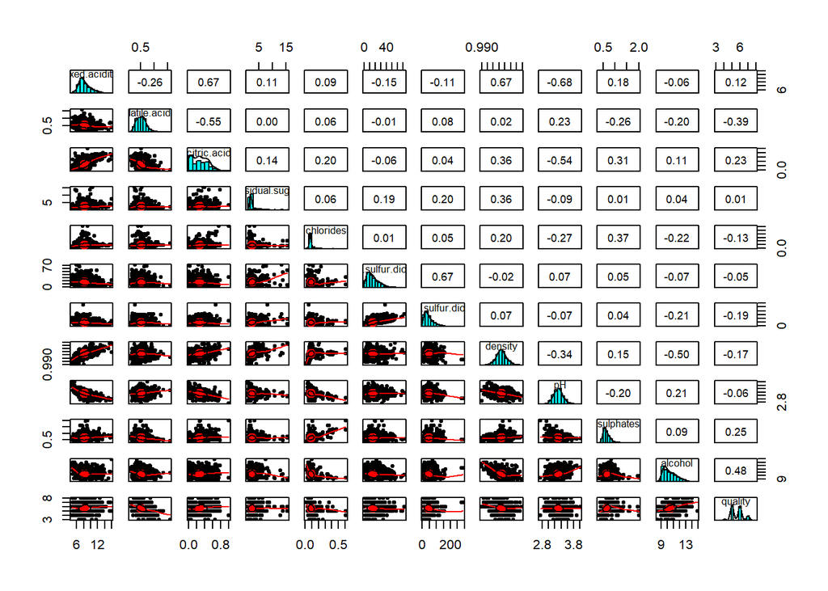

```r
    library(psych)
    pairs.panels(df)
```

> Datos de entrenamiento

```r
    set.seed(1)
    idx = sample(n, 0.9*n)
    train = df[idx,]; dim(train)
```

```
## [1] 1439   12
```

> Datos de prueba

```r
    test = df[-idx,]; dim(test)
```

```
## [1] 160  12
```

> Normalizamos el conjunto de entrenamiento en el rango de 0 a 1, tal como observamos lineas abajo, para todas las variables de clase.

```r
    # Normalizamos el conjunto de entrenamiento en el rango de 0 a 1
    normalize_train = function(x) (x - min(x))/(max(x) - min(x))
    train.norm = data.frame(apply(train[,-p], 2, normalize_train),
                            quality = train[,p])
    summary(train.norm)
```

```
##  fixed.acidity    volatile.acidity  citric.acid     residual.sugar
##  Min.   :0.0000   Min.   :0.0000   Min.   :0.0000   Min.   :0.00000
##  1st Qu.:0.2212   1st Qu.:0.2273   1st Qu.:0.1203   1st Qu.:0.06849
##  Median :0.2920   Median :0.3306   Median :0.3291   Median :0.08904
##  Mean   :0.3294   Mean   :0.3375   Mean   :0.3432   Mean   :0.11206
##  3rd Qu.:0.4115   3rd Qu.:0.4298   3rd Qu.:0.5443   3rd Qu.:0.11644
##  Max.   :1.0000   Max.   :1.0000   Max.   :1.0000   Max.   :1.00000
##    chlorides      free.sulfur.dioxide total.sulfur.dioxide    density
##  Min.   :0.0000   Min.   :0.00000     Min.   :0.00000      Min.   :0.0000
##  1st Qu.:0.1275   1st Qu.:0.08451     1st Qu.:0.05654      1st Qu.:0.4060
##  Median :0.1473   Median :0.18310     Median :0.11307      Median :0.4883
##  Mean   :0.1642   Mean   :0.20968     Mean   :0.14257      Mean   :0.4901
##  3rd Qu.:0.1714   3rd Qu.:0.29577     3rd Qu.:0.19788      3rd Qu.:0.5720
##  Max.   :1.0000   Max.   :1.00000     Max.   :1.00000      Max.   :1.0000
##        pH           sulphates         alcohol          quality
##  Min.   :0.0000   Min.   :0.0000   Min.   :0.0000   Min.   :3.000
##  1st Qu.:0.2920   1st Qu.:0.1333   1st Qu.:0.1692   1st Qu.:5.000
##  Median :0.3805   Median :0.1758   Median :0.2769   Median :6.000
##  Mean   :0.3818   Mean   :0.1979   Mean   :0.3118   Mean   :5.629
##  3rd Qu.:0.4602   3rd Qu.:0.2424   3rd Qu.:0.4154   3rd Qu.:6.000
##  Max.   :1.0000   Max.   :1.0000   Max.   :1.0000   Max.   :8.000
```

#### 4.3.3.2 Regresión lineal

> Este no es siempre el mejor modelo, pero está bien para empezar, para que tengamos un sentido básico de la relación entre la variable independiente y la variable dependiente y=f(x).

> Primero, verificaré la normalidad de la variable dependiente usando la prueba de Shapiro-Wilk.

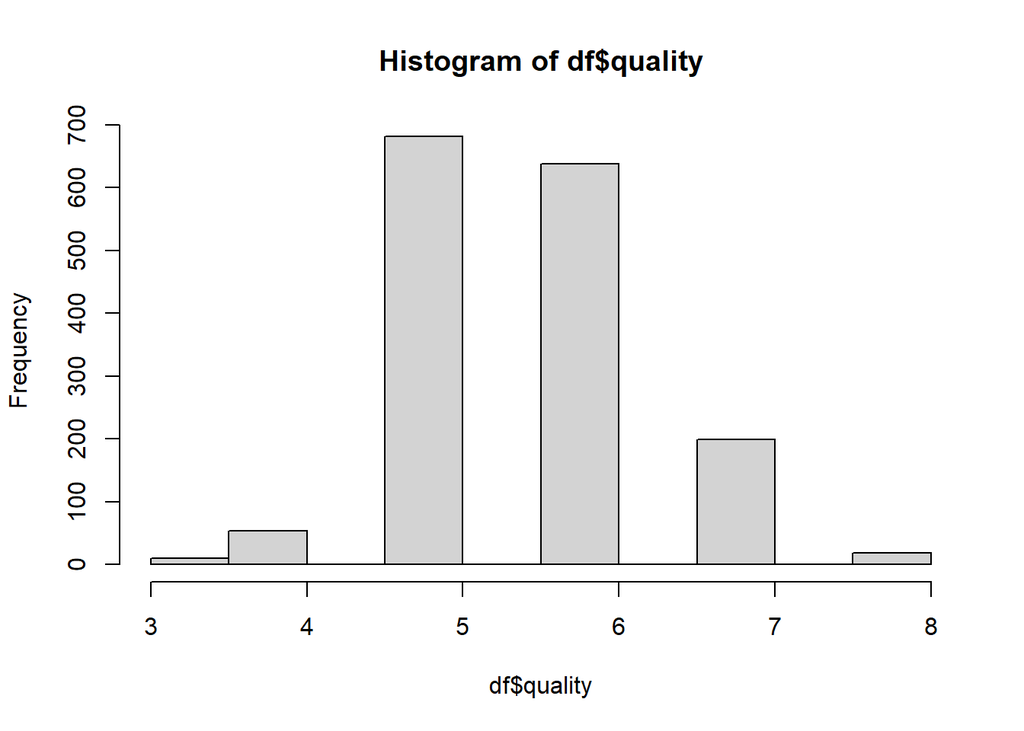

```r
    hist(df$quality)
```

```r
    #No pasó la prueba de normalidad, por lo que el modelo lineal puede tener un problema
    shapiro.test(df$quality)
```

```
##
##  Shapiro-Wilk normality test
##
## data:  df$quality
## W = 0.85759, p-value < 2.2e-16
```

> La variable dependiente no pasa la prueba de normalidad ( p-value < 2.2e-16), por lo que no se cumple un supuesto de regresión lineal. Además, como vemos en la gráfica de pares, la relación entre las variables independientes y las variables dependientes no es completamente lineal. También existe cierta colinealidad entre las variables independientes. Cualquiera de ellos podría sabotear el rendimiento del modelo lineal.

> Ahora realizamos la regresión lineal tal como se observa lineas abajo, observamos que la corte con eje Y es igual a 5.6615.

```r
    tr.lm = lm(quality~., data = train.norm)
    summary(tr.lm)
```

```
##
## Call:
## lm(formula = quality ~ ., data = train.norm)
##
## Residuals:
##      Min       1Q   Median       3Q      Max
## -2.64705 -0.36518 -0.04538  0.44322  2.01675
##
## Coefficients:
##                      Estimate Std. Error t value Pr(>|t|)
## (Intercept)            5.6615     0.1437  39.393  < 2e-16 ***
## fixed.acidity          0.1628     0.3062   0.532 0.595058
## volatile.acidity      -1.3054     0.1558  -8.378  < 2e-16 ***
## citric.acid           -0.1371     0.1229  -1.116 0.264528
## residual.sugar         0.3472     0.2284   1.520 0.128732
## chlorides             -0.6822     0.2098  -3.251 0.001175 **
## free.sulfur.dioxide    0.2343     0.1643   1.426 0.154145
## total.sulfur.dioxide  -0.8314     0.2195  -3.787 0.000159 ***
## density               -0.2452     0.3092  -0.793 0.427865
## pH                    -0.4944     0.2285  -2.163 0.030695 *
## sulphates              1.4637     0.1973   7.420 2.01e-13 ***
## alcohol                1.8063     0.1798  10.044  < 2e-16 ***
## ---
## Signif. codes:  0 '***' 0.001 '**' 0.01 '*' 0.05 '.' 0.1 ' ' 1
##
## Residual standard error: 0.6468 on 1427 degrees of freedom
## Multiple R-squared:  0.3509, Adjusted R-squared:  0.3459
## F-statistic: 70.13 on 11 and 1427 DF,  p-value: < 2.2e-16
```